# Part II - Reasons for departure delay and its change over time

## by Julia Kinday

## Investigation Overview

In this data set I looked into departure delays, their destribution, time trends and correlations with reported reasonf for delay.

## Dataset Overview

The dataset is 22000 sample of US domestic flights data taken from 22 separate file, each representing one year between 1987 and 2008. The features included: carriers, arrival and departure delays, reasons for delays. The delay reason presented beginning from 2003.

## Departure Delay Distribution

The feature distribution is hightly right skewed with many outliers, values varie from negative values in original data to 1433 minuts in presented sample, but most delays are within 1-60 minutes.

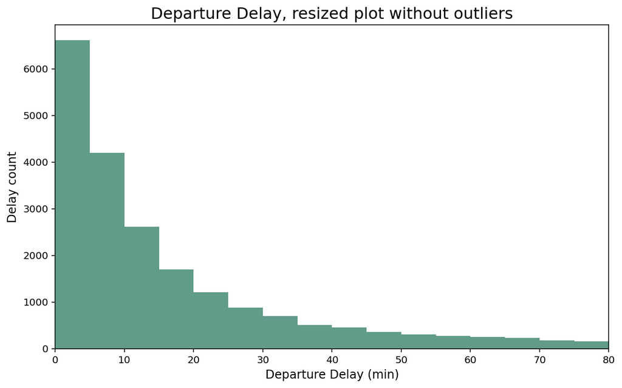

## Delay time trend over 22 years

A time plot shows increase in mean departure delay and its standart deviation over the years despite the same amount of data sampled for each year. This may probably mean that flights frequency increases as industry develops and airports become more busy.

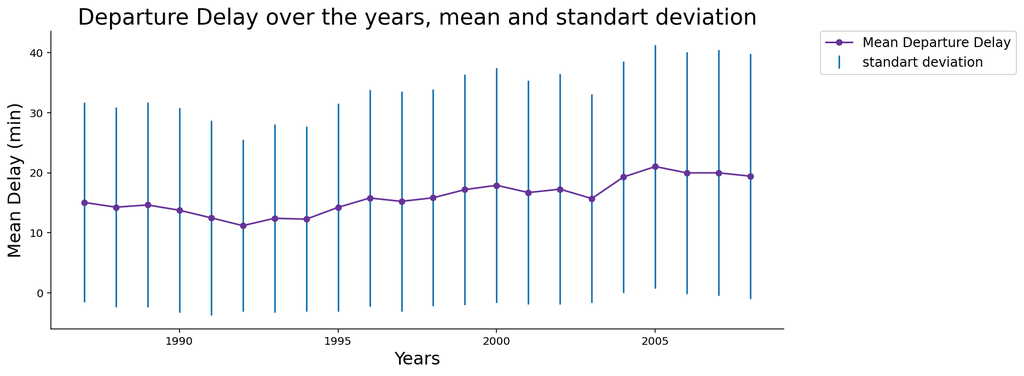

## Top 5 airlines

Looking into carriers and their proportions shows that 5 out of 29 carriers are responsible for more than 60% of delays but at the same time their mean departure delay are relatively low.

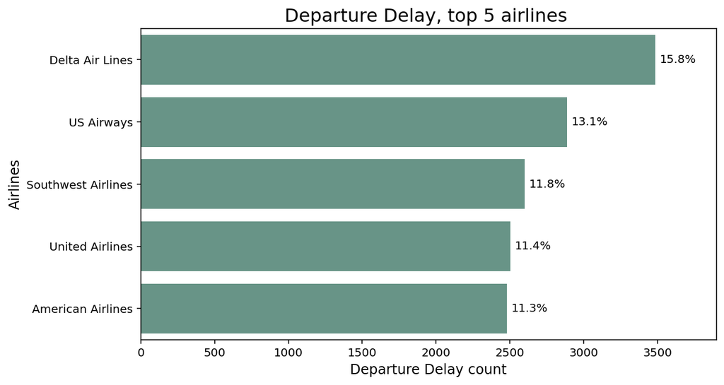

## Departure Delay over the years, top 5 busiest airlines

On the timeline plot, one of the top busiest aircompanies, Southwest Airlines has interesting change of mean delay: first 10 years of observation it was higher that others then in 2005 we see constant decrease. Other 4 carriers show slow increase in their departure delay means with a sharp increase at 2003, probably because the new report system was implemented and data became more accurate.

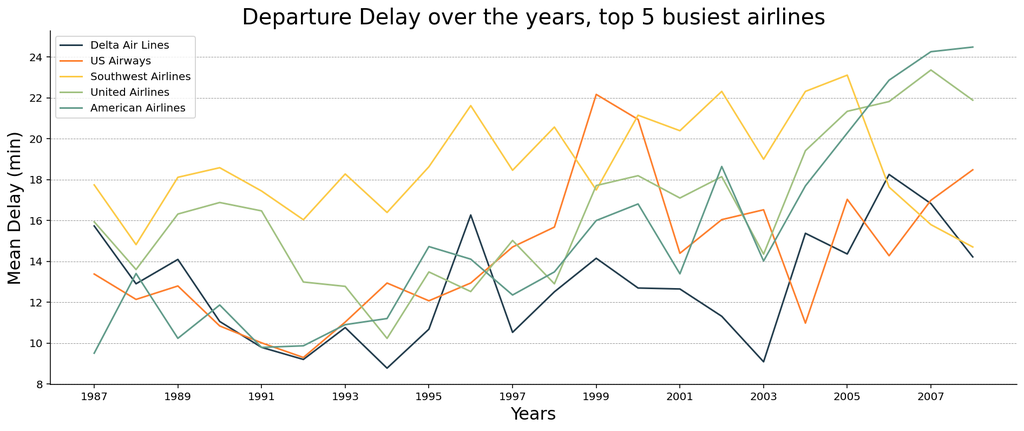

## Average delay duration by delay cause

As to reported reasons for delays, 'CarrierDelay' and 'LateAircraftDelay' have stronger correlation with departure delays. Weather shows to have not so huge impact on delay average, LateAircraftDelay tends to be longer at the beginning of the year and CarrierDelay shows that avialines perform evenly with small decrease in November.

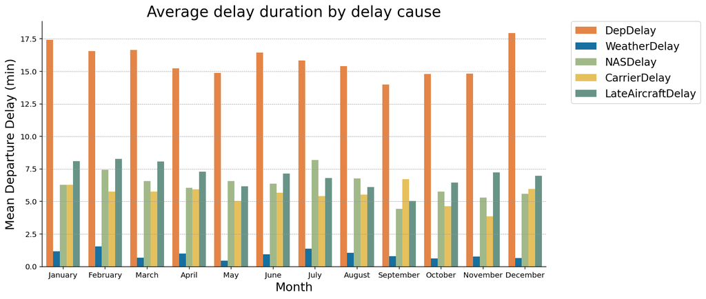